# Tugas-Pertemuan-5

Aliyah Nadhratunnaim

2025-10-02

# 1 Import Data

```r
library(ggplot2)
library(tsibble)
library(tseries)
library(MASS)
set.seed(1087)
```

```r
df <- read.csv("~/Aliyah/SEMESTER 5/MPDW/data_aliyah (1).csv")
head(df)
```

```
##        Date     Close   Volume
## 1 9/13/2024 11769.697 12601300
## 2 9/17/2024 11144.979 45242600
## 3 9/18/2024 10720.170 34909700
## 4 9/19/2024 11020.034 36434400
## 5 9/20/2024  8821.025 17045100
## 6 9/23/2024  7071.813 12591300
```

```r
df$Date <- as.Date(df$Date, format = "%m/%d/%Y")
head(df)
```

```
##         Date     Close   Volume
## 1 2024-09-13 11769.697 12601300
## 2 2024-09-17 11144.979 45242600
## 3 2024-09-18 10720.170 34909700
## 4 2024-09-19 11020.034 36434400
## 5 2024-09-20  8821.025 17045100
## 6 2024-09-23  7071.813 12591300
```

```r
library(dplyr)
df <- df %>%
  select(Date, Close)
head(df)
```

```
##         Date     Close
## 1 2024-09-13 11769.697
## 2 2024-09-17 11144.979
## 3 2024-09-18 10720.170
## 4 2024-09-19 11020.034
## 5 2024-09-20  8821.025
## 6 2024-09-23  7071.813
```

## 1.1 Pembagian data

Data dibagi menjadi 90% data train dan 10% data latih

```r
# hitung jumlah data
n <- nrow(df)
n_train <- floor(0.9 * n)

# bagi data
training <- df[1:n_train, ]
testing  <- df[(n_train+1):n, ]

# ubah ke time series
train <- ts(training$Close)
test  <- ts(testing$Close)
```

```r
n_train
```

```
## [1] 99
```

# 2 Uji Kestasioneran Data

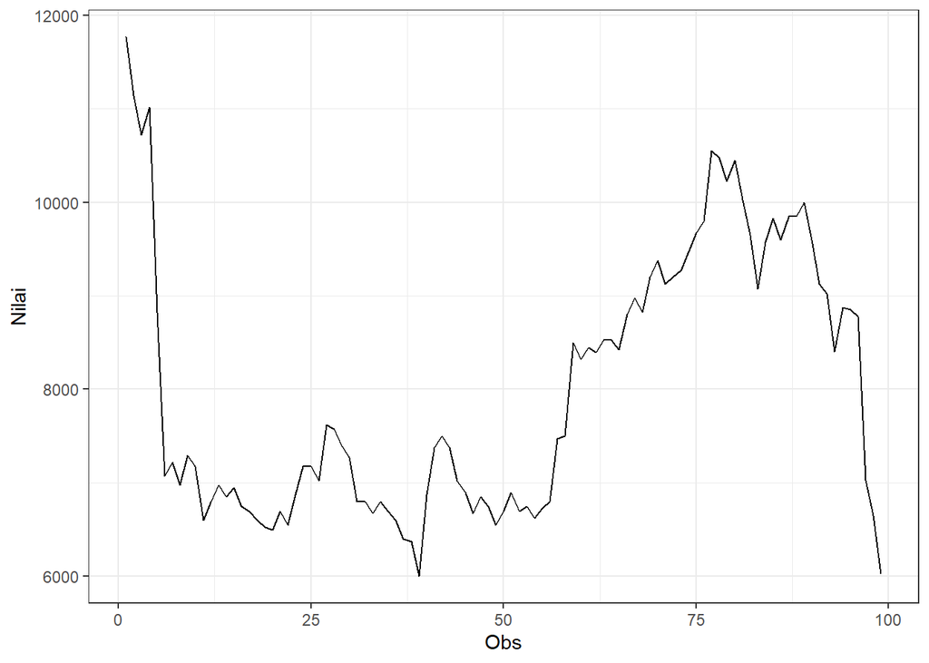

```r
index <- seq(1:99)

train |> as_tsibble() |>
  ggplot(aes(x = index, y = value)) +
  geom_line() + theme_bw() +
  xlab("Obs") + ylab("Nilai")
```

Berdasarkan plot time series tersebut, terlihat bahwa **data tidak stasioner dalam rataan** dan **tidak stasioner dalam ragam**, ditandai dengan adanya lebar pita pada plot yang cenderung berbeda.

```r
mean(train)
```

```
## [1] 7992.385
```

```r
var(train)
```

```
## [1] 2003509
```

## 2.1 Plot ACF

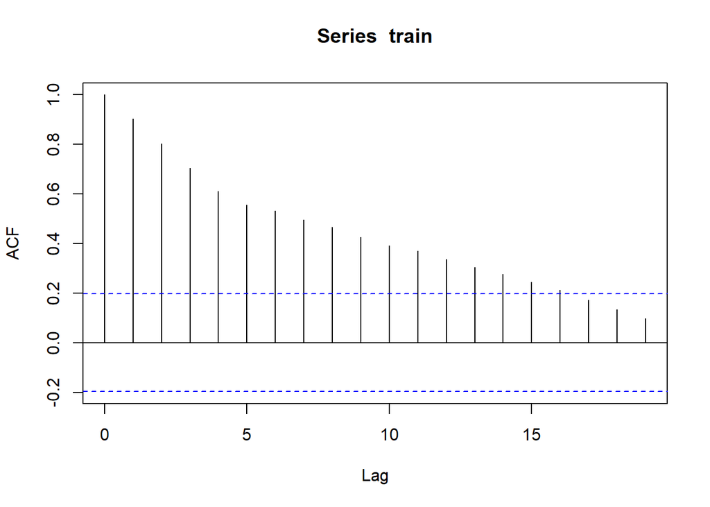

```r
acf(train)
```

Plot ACF menunjukkan korelasi yang menurun secara perlahan pada banyak lag, sehingga menjadi **indikasi kuat bahwa deret tidak stasioner**.

## 2.2 Uji ADF

```r
tseries::adf.test(train)
```

```
##
##  Augmented Dickey-Fuller Test
##
## data:  train
## Dickey-Fuller = -1.6847, Lag order = 4, p-value = 0.7071
## alternative hypothesis: stationary
```

Berdasarkan uji ADF tersebut, didapat p-value lebih besar dari taraf nyata 5% sehingga gagal tolak dan menandakan bahwa **data tidak stasioner dalam rataan**. Hal ini sesuai dengan hasil eksplorasi menggunakan plot time series dan plot ACF.

## 2.3 Uji Box-Cox

```r
# Uji Box-Cox
bc <- boxcox(
  train ~ index,
  lambda = seq(-4.0, -0.5, by = 0.001)
)
```

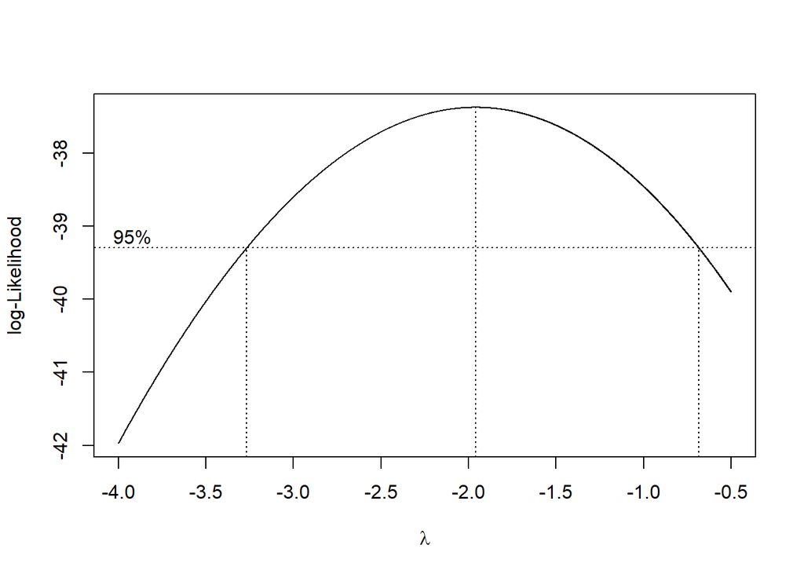

```r
# Nilai lambda optimum
lambda <- bc$x[which.max(bc$y)]
lambda
```

```
## [1] -1.959
```

```r
# Selang kepercayaan 95% untuk lambda
ci_lambda <- bc$x[bc$y > max(bc$y) - 0.5 * qchisq(0.95, 1)]

# Batas bawah dan batas atas
ci_lower <- min(ci_lambda)
ci_upper <- max(ci_lambda)

c(Batas_Bawah = ci_lower, Batas_Atas = ci_upper)
```

```
## Batas_Bawah  Batas_Atas
##      -3.267      -0.685
```

Hasil uji Box–Cox menunjukkan bahwa interval kepercayaan untuk nilai λ berada pada kisaran –3,267 hingga –0,685. Karena rentang tersebut tidak mencakup nilai λ = 1, maka terdapat indikasi bahwa data memiliki **ragam yang tidak homogen**.

# 3 Differencing

Untuk mengatasi data yang tidak stasioner, dilakukan differencing sebanyak satu kali.

```r
# Differencing pertama pada postrend
dt_rg_diff1 <- diff(train, differences = 1)
```

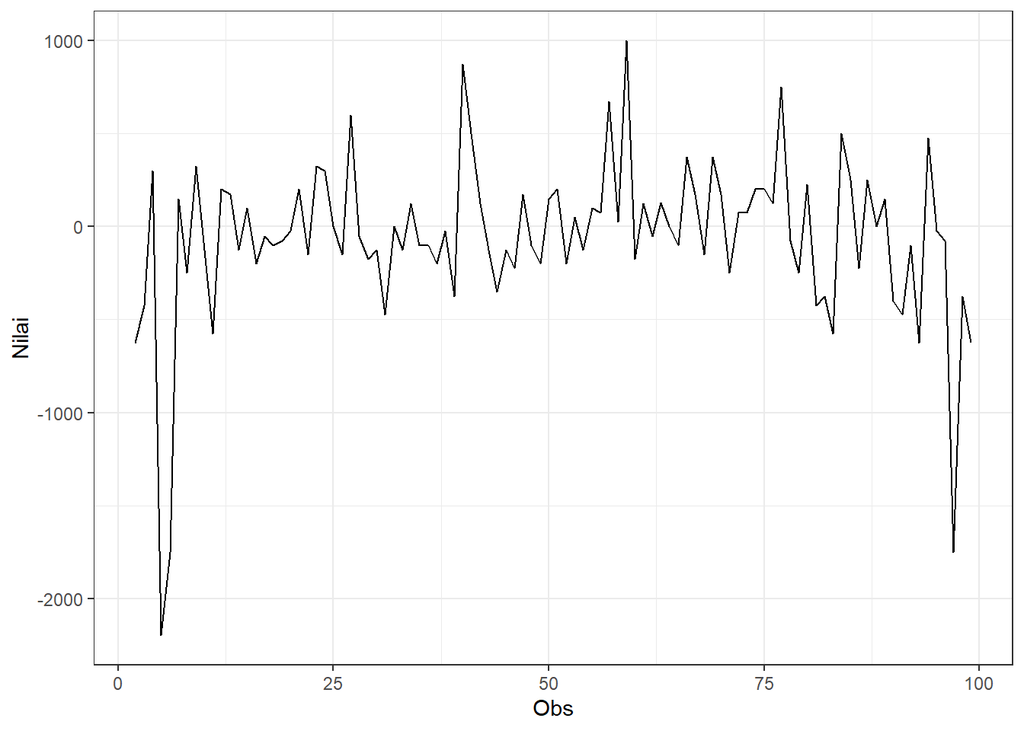

```r
dt_rg_diff1 |> as_tsibble() |>
  ggplot(aes(x = index, y = value)) +
  geom_line() + theme_bw() +
  xlab("Obs") + ylab("Nilai")
```

## 3.1 Plot ACF

Selanjutnya dilakukan eksplorasi pada plot ACF dan uji ADF untuk memeriksa apakah data telah stasioner dalam rataan.

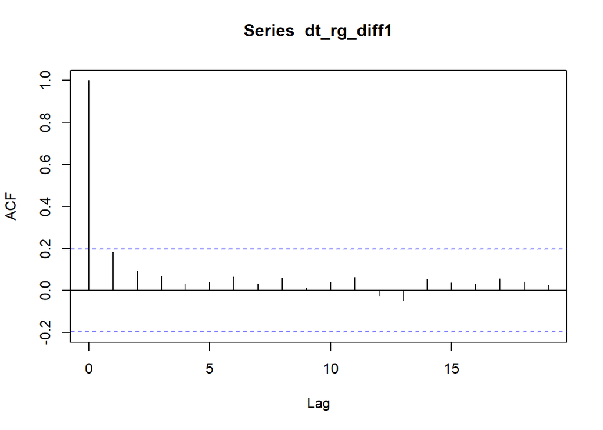

```r
acf(dt_rg_diff1)
```

## 3.2 Uji ADF

```r
tseries::adf.test(dt_rg_diff1)
```

```
##
##  Augmented Dickey-Fuller Test
##
## data:  dt_rg_diff1
## Dickey-Fuller = -5.0084, Lag order = 4, p-value = 0.01
## alternative hypothesis: stationary
```

Berdasarkan uji ADF tersebut, didapat p-value lebih kecil dari taraf nyata 5% sehingga tolak $H_0$ dan menandakan bahwa **data stasioner dalam rataan**. Hal ini sesuai dengan hasil eksplorasi menggunakan plot time series dan plot ACF.

## 3.3 Uji Box-Cox

```r
index1 <- seq(1:98)

# Uji Box-Cox
bc <- boxcox(
  dt_rg_diff1 - min(dt_rg_diff1) + 1 ~ index1,
  lambda = seq(0, 5, by = 0.001)
)
```

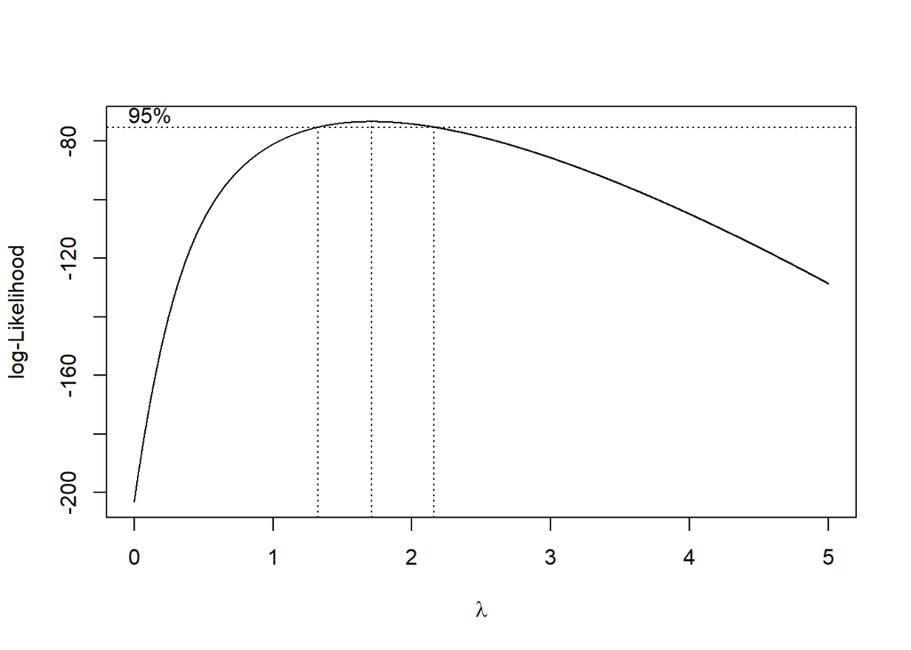

```r
# Nilai lambda optimum (dibulatkan)
lambda <- bc$x[which.max(bc$y)]
lambda
```

```
## [1] 1.708
```

```r
# Selang kepercayaan 95% untuk lambda
ci_lambda <- bc$x[bc$y > max(bc$y) - 0.5 * qchisq(0.95, 1)]

# Batas bawah dan batas atas
ci_lower <- min(ci_lambda)
ci_upper <- max(ci_lambda)

c(Batas_Bawah = ci_lower, Batas_Atas = ci_upper)
```

```
## Batas_Bawah  Batas_Atas
##       1.323       2.160
```

Hasil uji Box–Cox menunjukkan bahwa nilai λ optimum adalah 1.708 dengan interval kepercayaan 95% sebesar (1.323–2.160). Karena selang tersebut tidak memuat nilai λ = 1, maka dapat disimpulkan bahwa **data tidak stasioner dalam ragam sehingga diperlukan transformasi.**

# 4 Transformasi Box-Cox

```r
# Data digeser agar positif
y_shift <- dt_rg_diff1 - min(dt_rg_diff1) + 1

# Transformasi Box-Cox dengan lambda ~ 2
y_bc <- y_shift^2
```

```r
index <- seq(1:98)

# Uji Box-Cox
bc <- boxcox(
  y_bc ~ index,
  lambda = seq(-2, 5, by = 0.001)
)
```

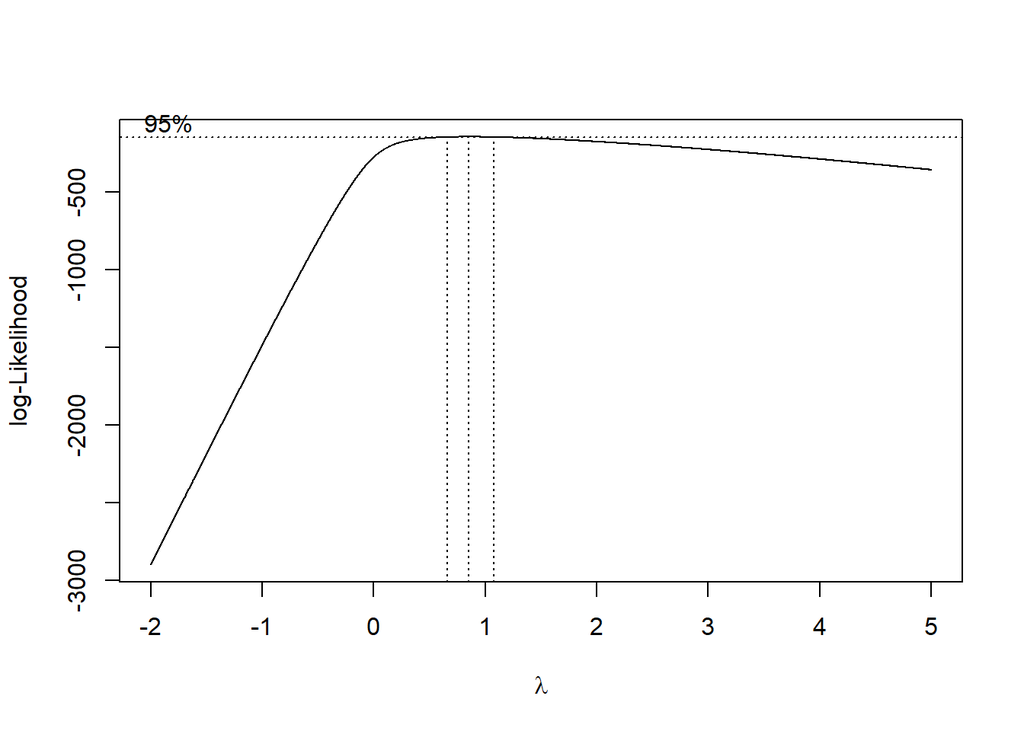

```r
# Nilai lambda optimum (dibulatkan)
lambda <- bc$x[which.max(bc$y)]
lambda
```

```
## [1] 0.854
```

```r
# Selang kepercayaan 95% untuk lambda
ci_lambda <- bc$x[bc$y > max(bc$y) - 0.5 * qchisq(0.95, 1)]

# Batas bawah dan batas atas
ci_lower <- min(ci_lambda)
ci_upper <- max(ci_lambda)

c(Batas_Bawah = ci_lower, Batas_Atas = ci_upper)
```

```
## Batas_Bawah  Batas_Atas
##       0.662       1.080
```

Hasil uji Box–Cox menunjukkan bahwa nilai λ optimum adalah 0.854 dengan interval kepercayaan 95% sebesar (0.662–1.080). Karena selang tersebut memuat nilai λ = 1, maka dapat disimpulkan bahwa **data stasioner dalam ragam.**